# Data Analysis

# Load Data

```r
data_path <- "../data/original/train.csv"
voice <- read.csv(data_path)
head(voice)
```

```
##   id meanfreq       sd   median      Q25      Q75      IQR        skew
## 1  0 3521.667 2332.212 2997.294 1660.408 4621.867 2961.459  0.11656897
## 2  1 4189.998 2430.977 4302.741 1832.028 5901.071 4069.043  0.04560770
## 3  2 3154.455 2150.497 2609.968 1460.612 4053.928 2593.316 -0.16147499
## 4  3 4384.338 3029.302 3426.479 1596.072 7283.314 5687.242  0.02416762
## 5  4 4557.150 3158.111 4543.116 1608.165 8074.335 6466.170  0.11711588
## 6  5 4069.004 2983.199 2565.487 1305.284 6961.581 5656.297  0.13049391
##        kurt   sp.ent         sfm     mode centroid  meanfun   minfun   maxfun
## 1 0.9817728 2.308696 0.008450270 1761.333 3521.667 32.33476 153.1934 3995.790
## 2 0.9214181 3.522410 0.022862796 2095.499 4189.998 42.56545 154.0434 3993.462
## 3 0.3882481 2.027891 0.006853276 1577.728 3154.455 26.15712 153.4610 3995.524
## 4 1.4739316 4.823092 0.084471270 2192.669 4384.338 37.56627 153.6399 3994.671
## 5 1.2885699 3.820815 0.100988194 2279.075 4557.150 29.34924 153.8535 3994.646
## 6 0.7668548 3.726702 0.073939204 2035.002 4069.004 29.89368 153.2515 3995.253
##      meandom       mindom    maxdom   dfrange  modindx      age gender accent
## 1 0.06084856 9.842593e-04 194.17128 194.17029 5914.581 twenties female canada
## 2 0.04495757 7.060266e-04 102.27859 102.27788 7693.945 twenties female canada
## 3 0.08144125 2.950821e-04 164.99316 164.99287 5261.606 twenties female canada
## 4 0.01039643 3.165859e-08  29.66787  29.66787 7942.756      nan    nan    nan
## 5 0.01848914 9.267869e-07  85.19259  85.19259 8383.634      nan    nan    nan
## 6 0.01521549 6.052965e-07  32.57839  32.57839 7575.469      nan    nan    nan
```

# Analyze Data

## MeanFreq

### Basic Analysis

We firstly load the data and draw a histogram of the `meanfreq` column.

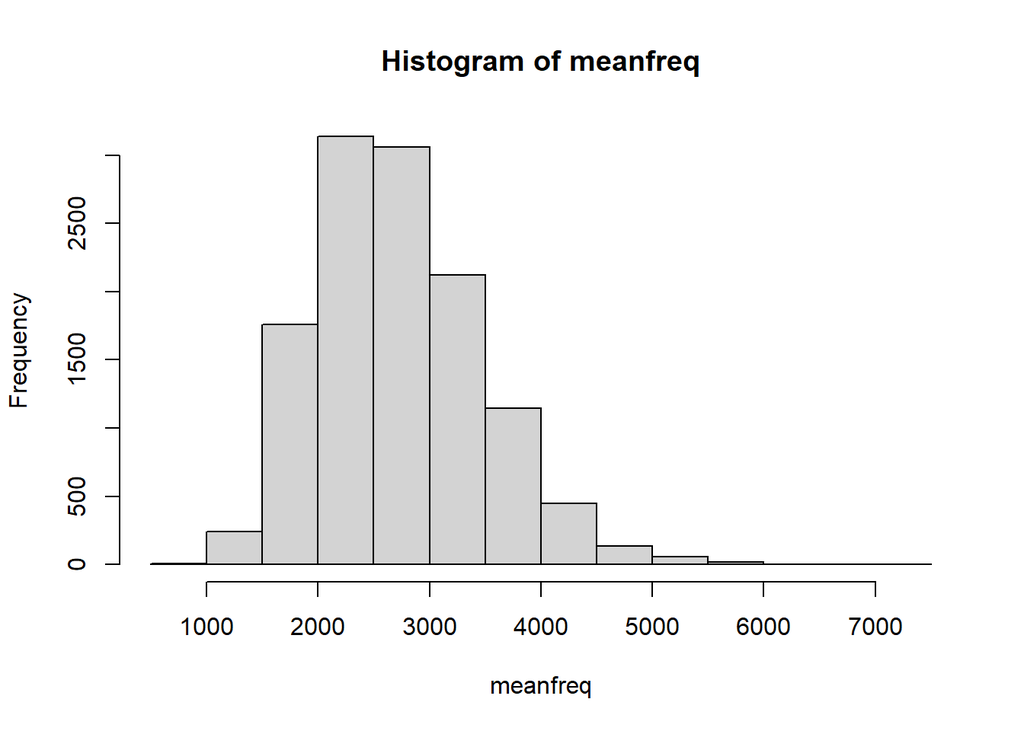

```r
meanfreq <- voice$meanfreq
hist(meanfreq)
```

Then, we calculate the mean and standard deviation of the `meanfreq` column.

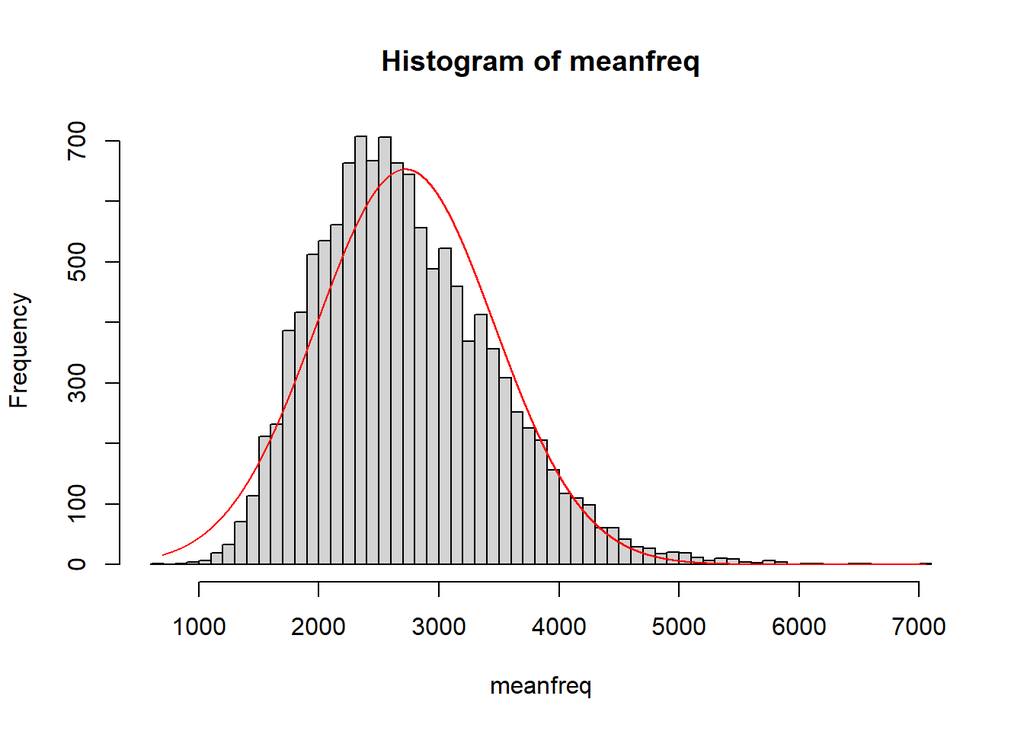

```r
# hist of meanfreq
hist(meanfreq, breaks = 80, main = "Histogram of meanfreq", xlab = "meanfreq")
# impose a normal curve on the histogram
xpt <- seq(698, 7056, by = 0.1)
n_den <- dnorm(xpt, mean = mean(meanfreq), sd = sd(meanfreq))
ypt <- n_den * length(meanfreq) * 100
lines(xpt, ypt, col = "red")
```

#### QQ plot for meanfreq

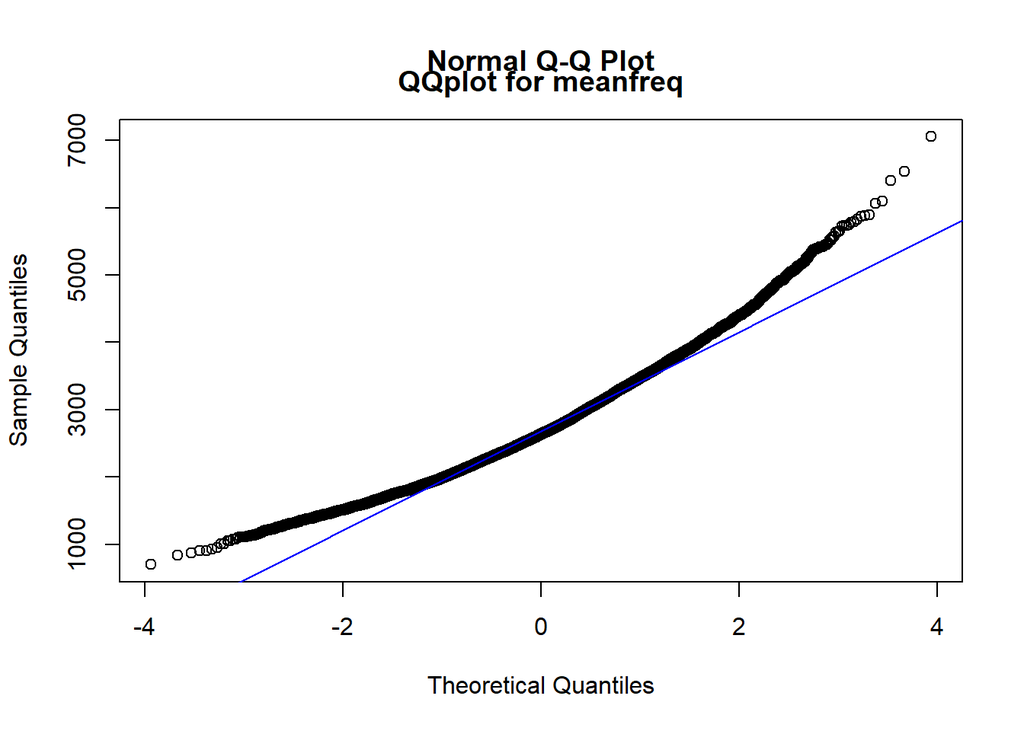

```r
# QQplot of meanfreq
qqnorm(meanfreq)
qqline(meanfreq, col = "blue")
title("QQplot for meanfreq", line = 1) # Place title on the first line
```

#### shapiro test

Shapiro test-sample must be less than 5000. Therefore, we will take a sample of 5000 for 100 times

```r
pvalue <- numeric(100)
for (i in 1:100) {
  meanfreq_sample <- sample(meanfreq, 5000)
  shapiro.test(meanfreq_sample)
  pvalue[i] <- shapiro.test(meanfreq_sample)$p.value
}
pvalue > 0.05
```

```
##   [1] FALSE FALSE FALSE FALSE FALSE FALSE FALSE FALSE FALSE FALSE FALSE FALSE
##  [13] FALSE FALSE FALSE FALSE FALSE FALSE FALSE FALSE FALSE FALSE FALSE FALSE
##  [25] FALSE FALSE FALSE FALSE FALSE FALSE FALSE FALSE FALSE FALSE FALSE FALSE
##  [37] FALSE FALSE FALSE FALSE FALSE FALSE FALSE FALSE FALSE FALSE FALSE FALSE
##  [49] FALSE FALSE FALSE FALSE FALSE FALSE FALSE FALSE FALSE FALSE FALSE FALSE
##  [61] FALSE FALSE FALSE FALSE FALSE FALSE FALSE FALSE FALSE FALSE FALSE FALSE
##  [73] FALSE FALSE FALSE FALSE FALSE FALSE FALSE FALSE FALSE FALSE FALSE FALSE
##  [85] FALSE FALSE FALSE FALSE FALSE FALSE FALSE FALSE FALSE FALSE FALSE FALSE
##  [97] FALSE FALSE FALSE FALSE
```

Therefore, the data is not normally distributed.

### log-transformation

```r
meanfreq_trans <- log(meanfreq)
hist(
  meanfreq_trans,
  breaks = 80,
  main = "Histogram of log(meanfreq)",
  xlab = "log(meanfreq)"
)
range(meanfreq_trans)
```

```
## [1] 6.549486 8.861497
```

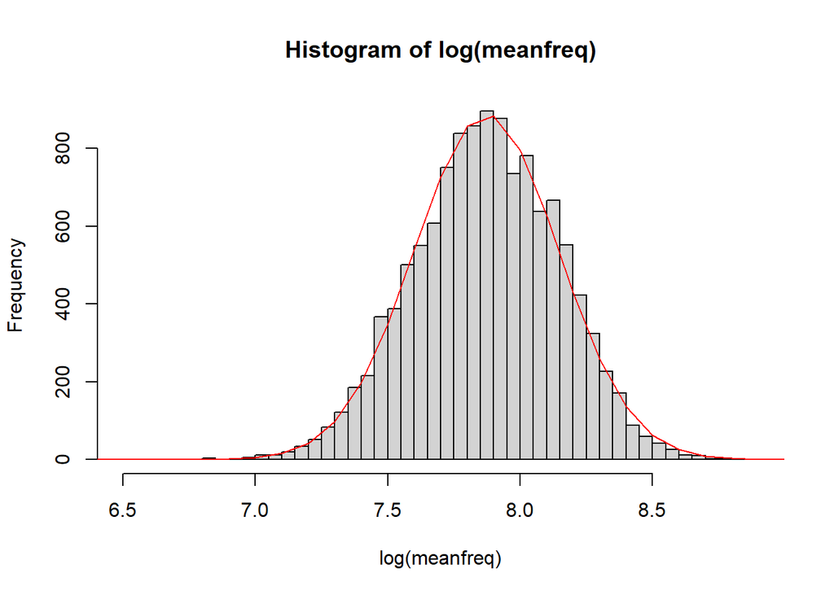

```r
# impose a normal curve on the histogram
xpt <- seq(6, 9, by = 0.1)
n_den <- dnorm(xpt, mean = mean(meanfreq_trans), sd = sd(meanfreq_trans))
ypt <- n_den * length(meanfreq_trans) * 0.05
lines(xpt, ypt, col = "red")
```

#### QQ plot for log-transformed meanfreq

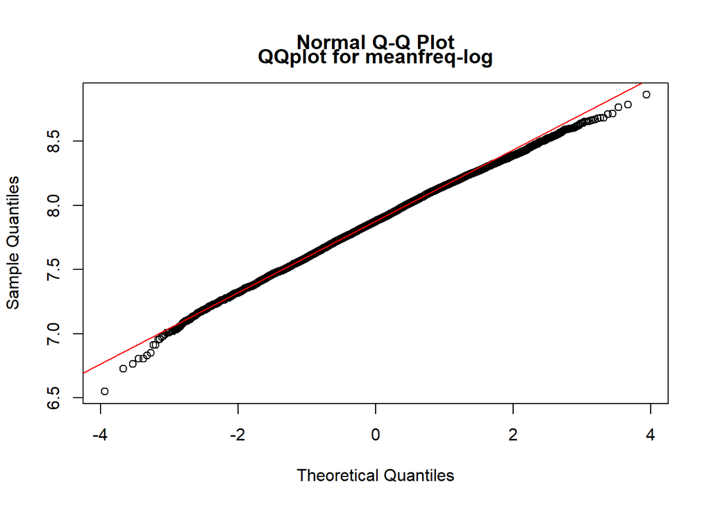

```r
qqnorm(meanfreq_trans)
qqline(meanfreq_trans, col = "red")
title("QQplot for meanfreq-log", line = 1) # Place title on the first line
```

## SD

### Basic Analysis

We firstly load the data and draw a histogram of the `sd` column.

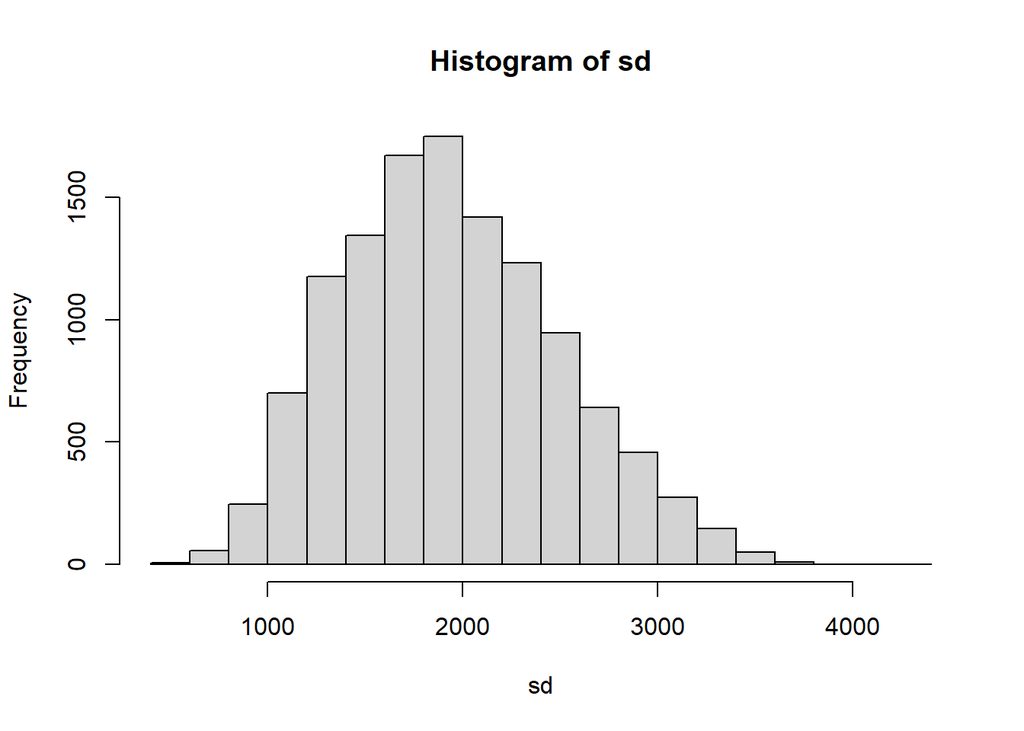

```r
sd <- voice$sd
hist(sd)
```

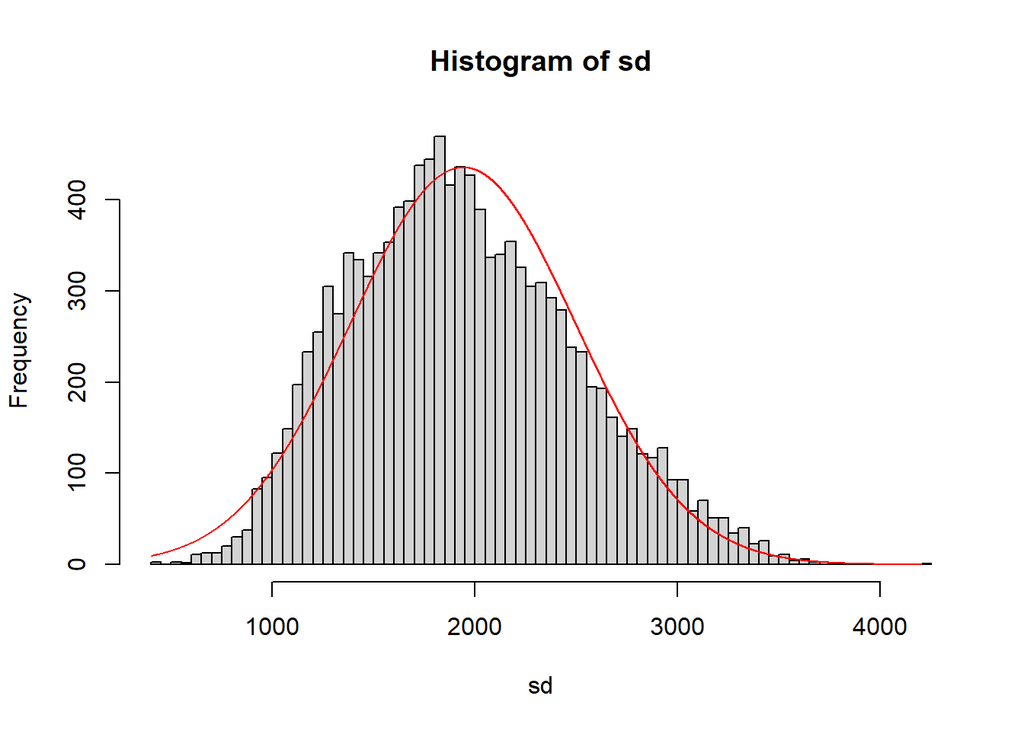

```r
hist(sd, breaks = 80, main = "Histogram of sd", xlab = "sd")
# impose a normal curve on the histogram
xpt <- seq(402, 4203, by = 0.1)
n_den <- dnorm(xpt, mean = mean(sd), sd = sd(sd))
ypt <- n_den * length(sd) * 50
lines(xpt, ypt, col = "red")
```

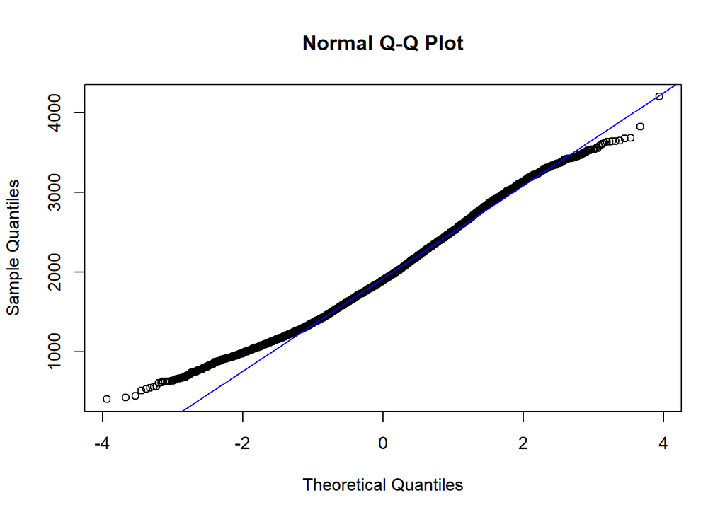

```r
qqnorm(sd)
qqline(sd, col = "blue")
```

### log-transformation

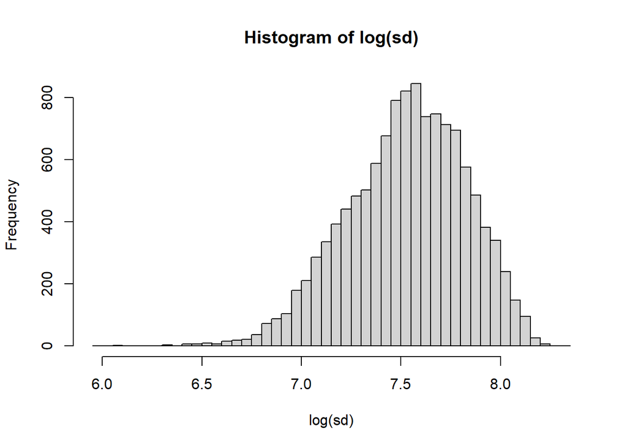

```r
# log-transformation of sd
sd_trans <- log(sd)
hist(sd_trans, breaks = 80, main = "Histogram of log(sd)", xlab = "log(sd)")
```

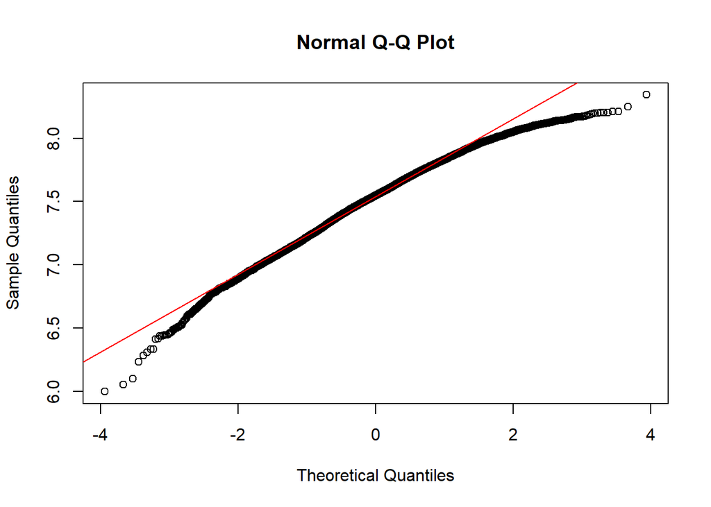

```r
qqnorm(sd_trans)
qqline(sd_trans, col = "red")
```

We found that after log-transformation, the data is even worse than before.

Therefore, we tried another way: $y=\log(x + 3000)$

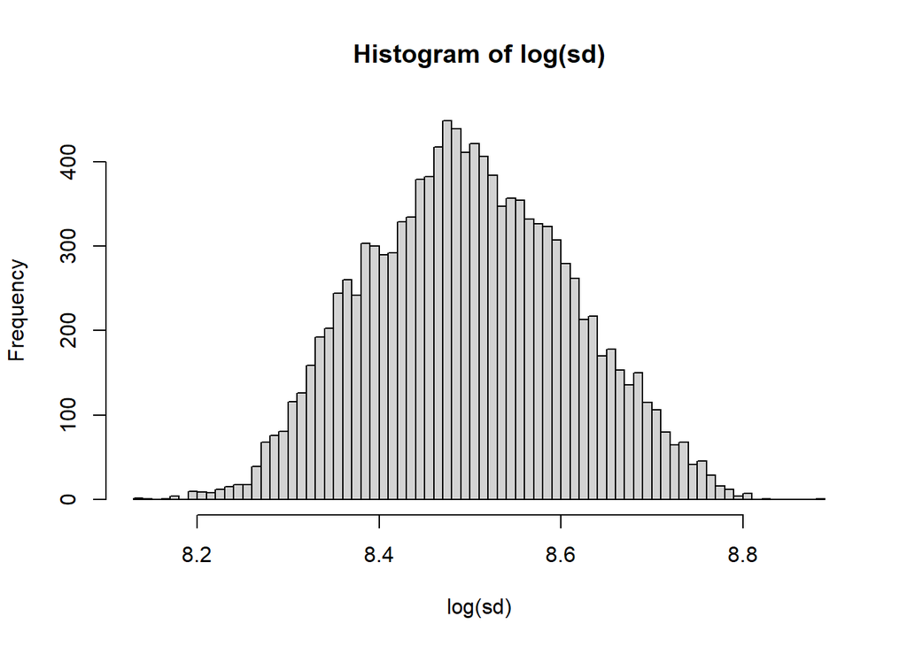

```r
sd_trans <- log(sd + 3000)
hist(sd_trans, breaks = 80, main = "Histogram of log(sd)", xlab = "log(sd)")
```

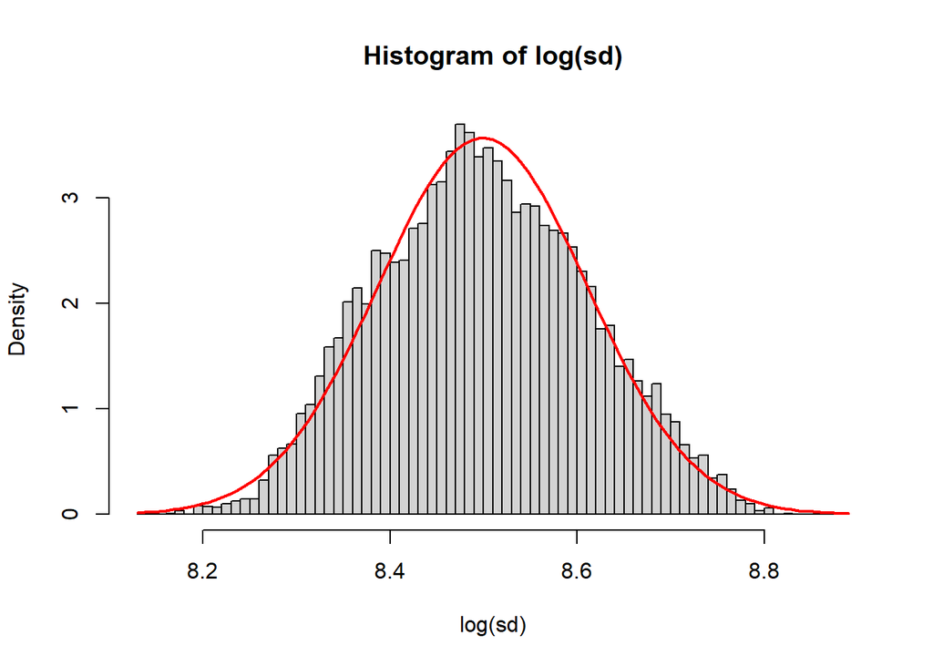

```r
hist(
  sd_trans,
  breaks = 80,
  main = "Histogram of log(sd)",
  xlab = "log(sd)",
  probability = TRUE
)
curve(
  dnorm(x, mean = mean(sd_trans), sd = sd(sd_trans)),
  col = "red",
  lwd = 2,
  add = TRUE
)
```

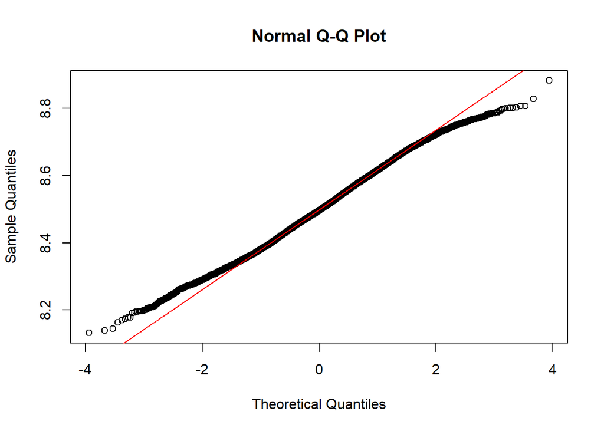

```r
qqnorm(sd_trans)
qqline(sd_trans, col = "red")
```

## Median

### Basic Analysis

We firstly load the data and draw a histogram of the `median` column.

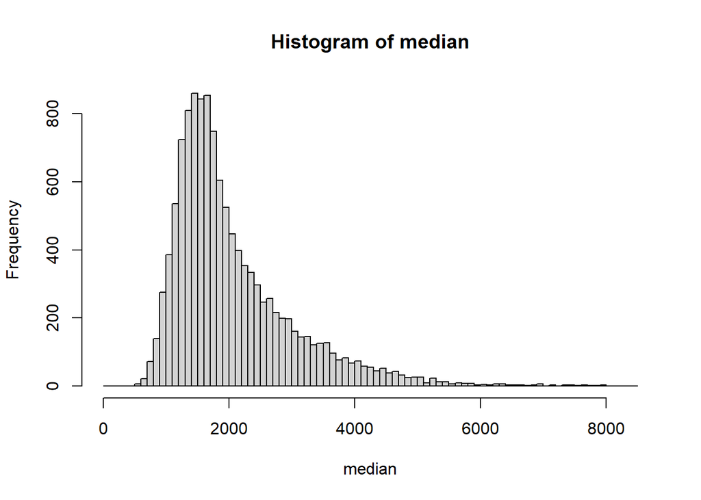

```r
median <- voice$median
hist(median, breaks = 80, main = "Histogram of median", xlab = "median")
```

Then, we calculate the mean and standard deviation of the `median` column.

```r
median_mean <- mean(median)
median_sd <- sd(median)
```

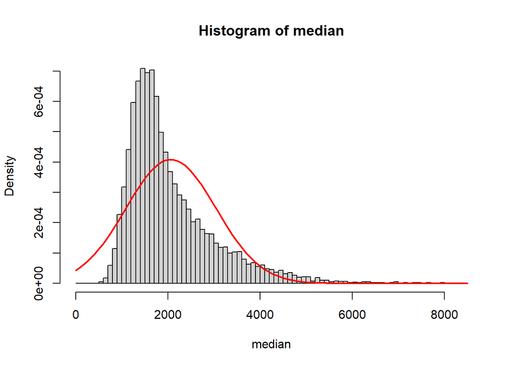

```r
hist(median, breaks = 80, main = "Histogram of median", xlab = "median", probability = TRUE)
curve(
  dnorm(x, mean = median_mean, sd = median_sd),
  col = "red",
  lwd = 2,
  add = TRUE
)
```

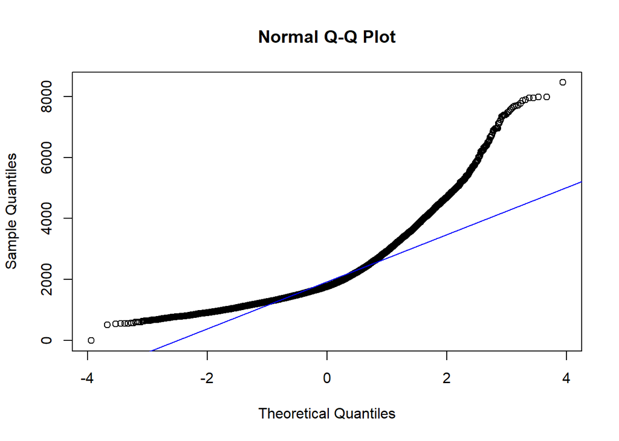

```r
qqnorm(median)
qqline(median, col = "blue")
```

### log-transformation

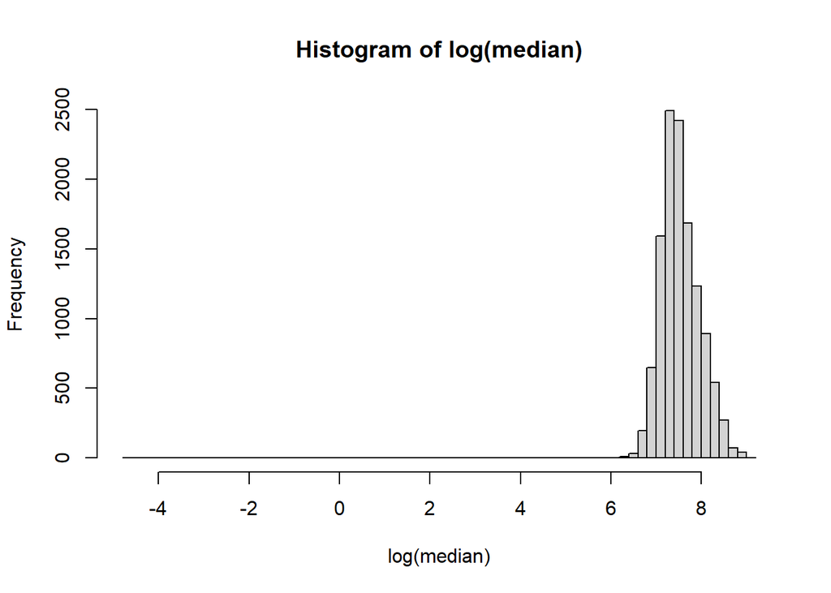

```r
median_trans <- log(median + 0.01)
hist(median_trans, breaks = 80, main = "Histogram of log(median)", xlab = "log(median)")
```

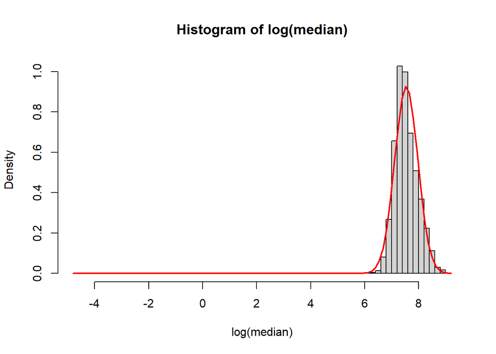

```r
hist(
  median_trans,
  breaks = 90,
  main = "Histogram of log(median)",
  xlab = "log(median)",
  probability = TRUE
)
curve(
  dnorm(x, mean = mean(median_trans), sd = sd(median_trans)),
  col = "red", lwd = 2,
  add = TRUE
)
```

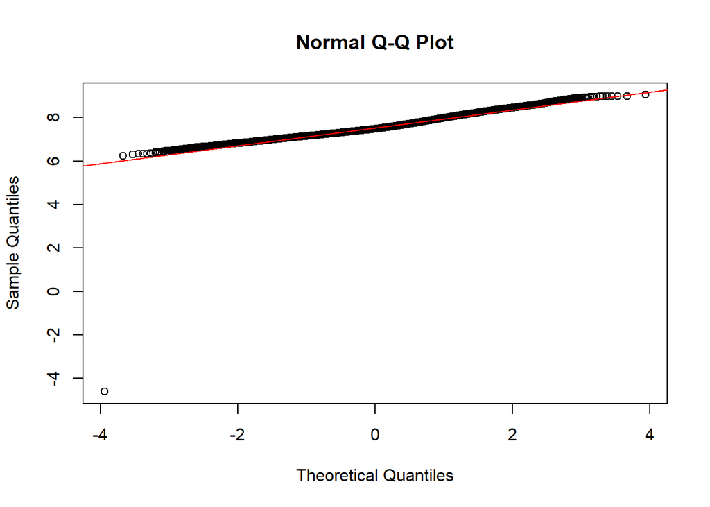

```r
qqnorm(median_trans)
qqline(median_trans, col = "red")
```

## Q25

### Basic Analysis

We firstly load the data and draw a histogram of the `Q25` column.

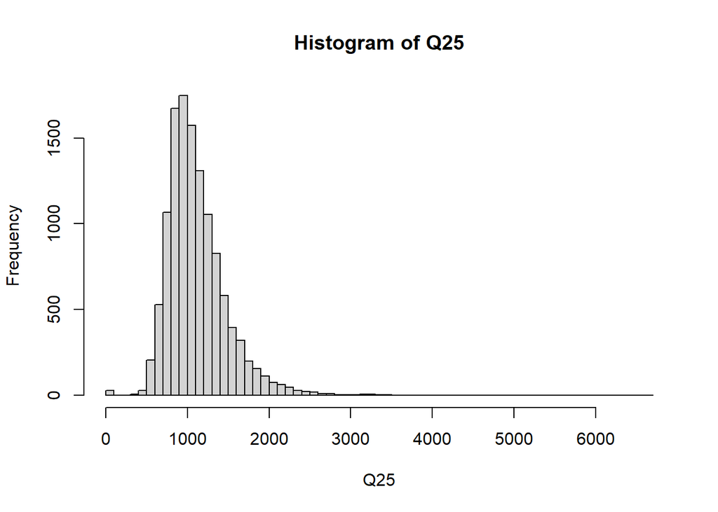

```r
Q25 <- voice$Q25
hist(Q25, breaks = 80, main = "Histogram of Q25", xlab = "Q25")
```

Then, we calculate the mean and standard deviation of the `Q25` column.

```r
Q25_mean <- mean(Q25)
Q25_sd <- sd(Q25)
```

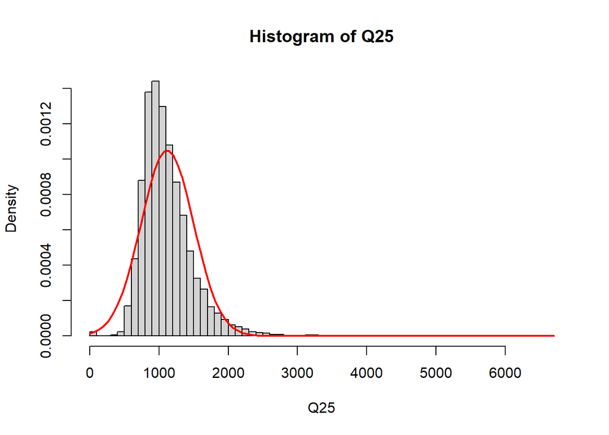

```r
hist(Q25, breaks = 80, main = "Histogram of Q25", xlab = "Q25", probability = TRUE)
curve(dnorm(x, mean = Q25_mean, sd = Q25_sd), col = "red", lwd = 2, add = TRUE)
```

#### QQ plot for Q25

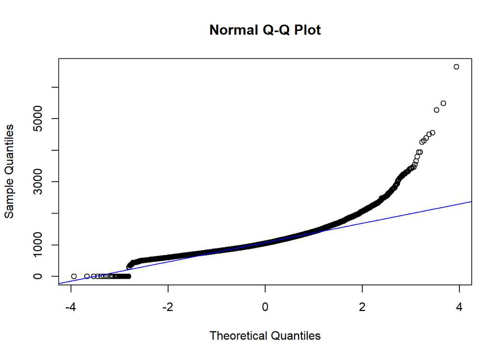

```r
qqnorm(Q25)
qqline(Q25, col = "blue")
```

### log-transformation

After multiple attempts to transform the `Q25` column, we found that the log-transformation with $f(x)=\log(x - \min(x) + 70)$ is the best transformation for this column.

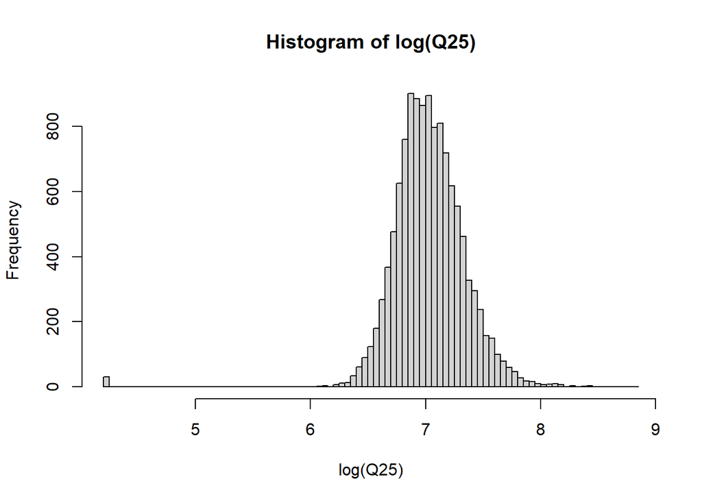

```r
Q25_trans <- log(Q25 - min(Q25) + 70)
hist(Q25_trans, breaks = 80, main = "Histogram of log(Q25)", xlab = "log(Q25)")
```

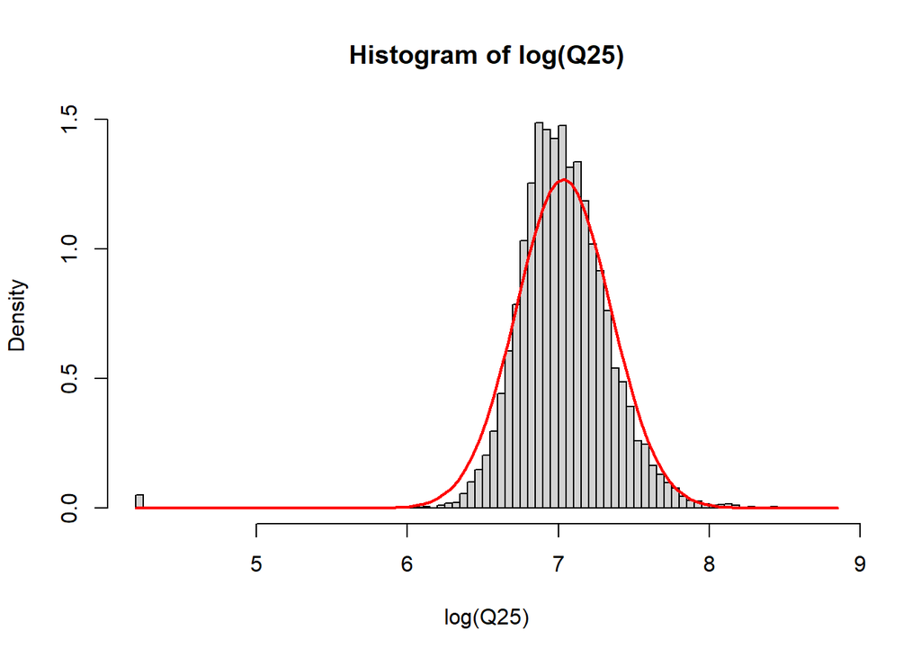

```r
hist(Q25_trans, breaks = 80, main = "Histogram of log(Q25)", xlab = "log(Q25)", probability = TRUE)
curve(dnorm(x, mean = mean(Q25_trans), sd = sd(Q25_trans)), col = "red", lwd = 2, add = TRUE)
```

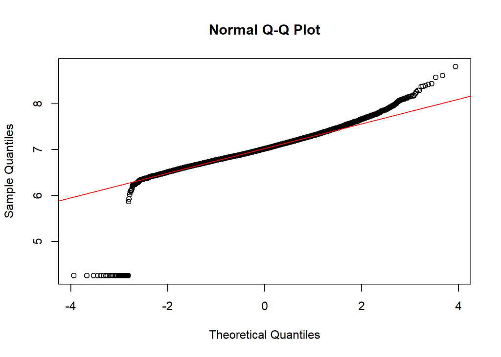

```r
qqnorm(Q25_trans)
qqline(Q25_trans, col = "red")
```

## Q75

### Basic Analysis

We firstly load the data and draw a histogram of the `Q75` column.

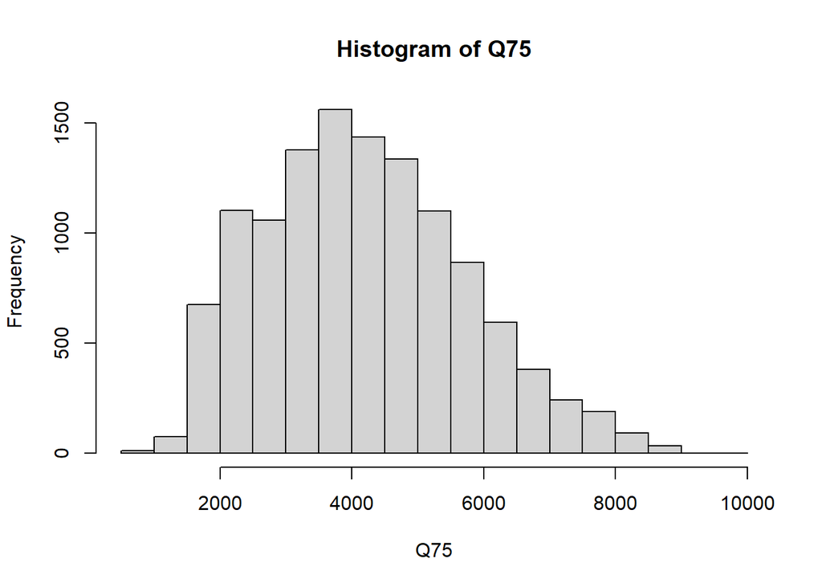

```r
Q75 <- voice$Q75
hist(Q75)
```

Then, we calculate the mean and standard deviation of the `Q75` column.

```r
Q75_mean <- mean(Q75)
Q75_sd <- sd(Q75)
print(paste("Mean of Q75:", Q75_mean))
```

```
## [1] "Mean of Q75: 4187.87067406675"
```

```r
print(paste("Standard deviation of Q75:", Q75_sd))
```

```
## [1] "Standard deviation of Q75: 1522.24666544973"
```

#### Histogram with overlaid normal curve

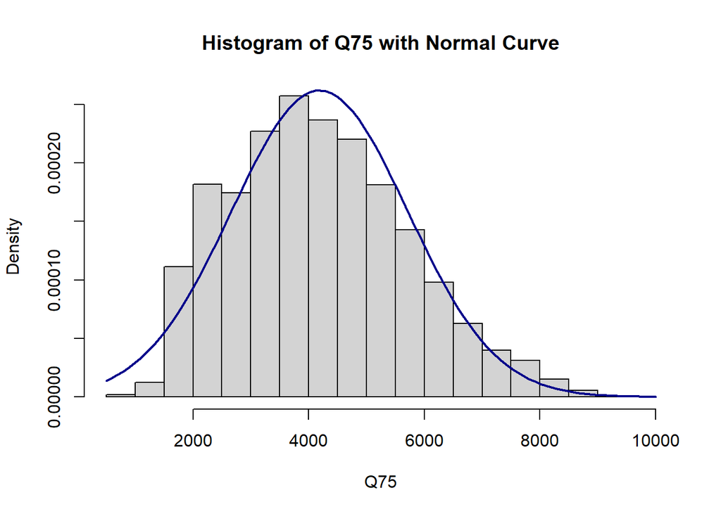

```r
hist(Q75, probability = TRUE, main = "Histogram of Q75 with Normal Curve", xlab = "Q75")
curve(dnorm(x, mean = Q75_mean, sd = Q75_sd), col = "darkblue", lwd = 2, add = TRUE, yaxt = "n")
```

#### QQ plot

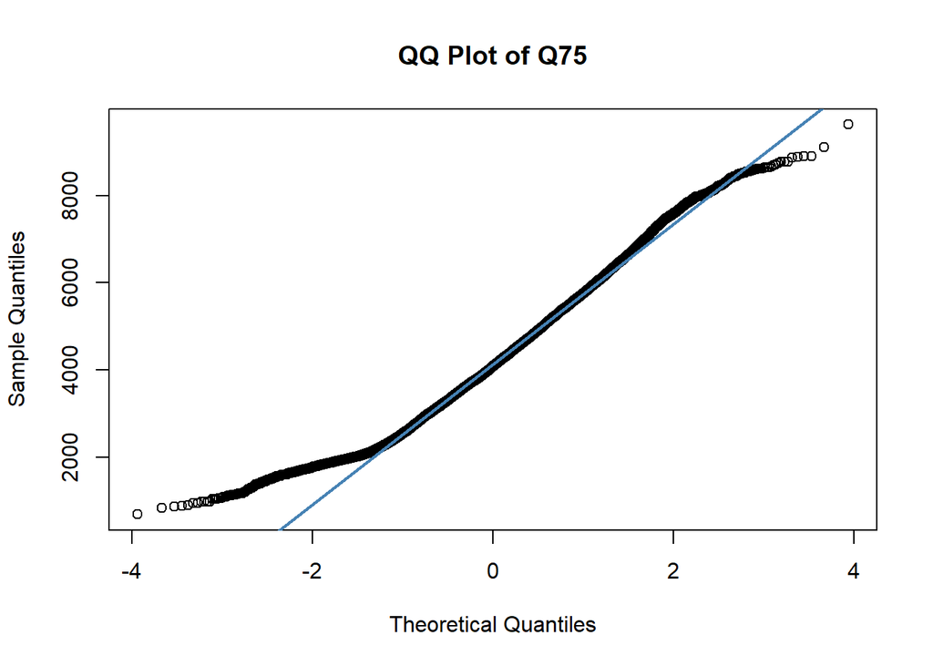

```r
qqnorm(Q75, main = "QQ Plot of Q75")
qqline(Q75, col = "steelblue", lwd = 2)
```

### Log-transformed `Q75`

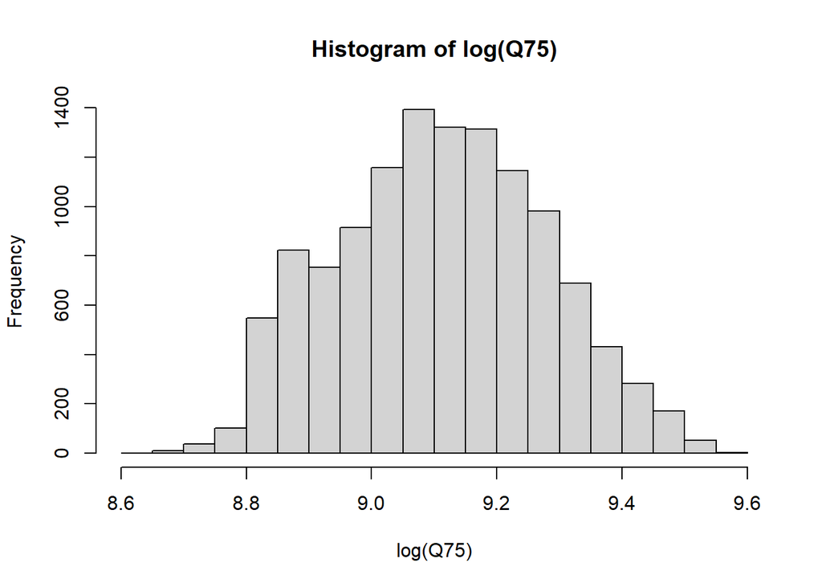

```r
Q75_trans <- log(Q75 + 5000)
hist(Q75_trans, breaks = 20, main = "Histogram of log(Q75)", xlab = "log(Q75)")
```

```r
Q75_trans_mean <- mean(Q75_trans)
Q75_trans_sd <- sd(Q75_trans)
print(paste("Mean of log-transformed Q75:", Q75_trans_mean))
```

```
## [1] "Mean of log-transformed Q75: 9.11206165864669"
```

```r
print(paste("Standard deviation of log-transformed Q75:", Q75_trans_sd))
```

```
## [1] "Standard deviation of log-transformed Q75: 0.164697259619145"
```

#### Histogram with overlaid normal curve

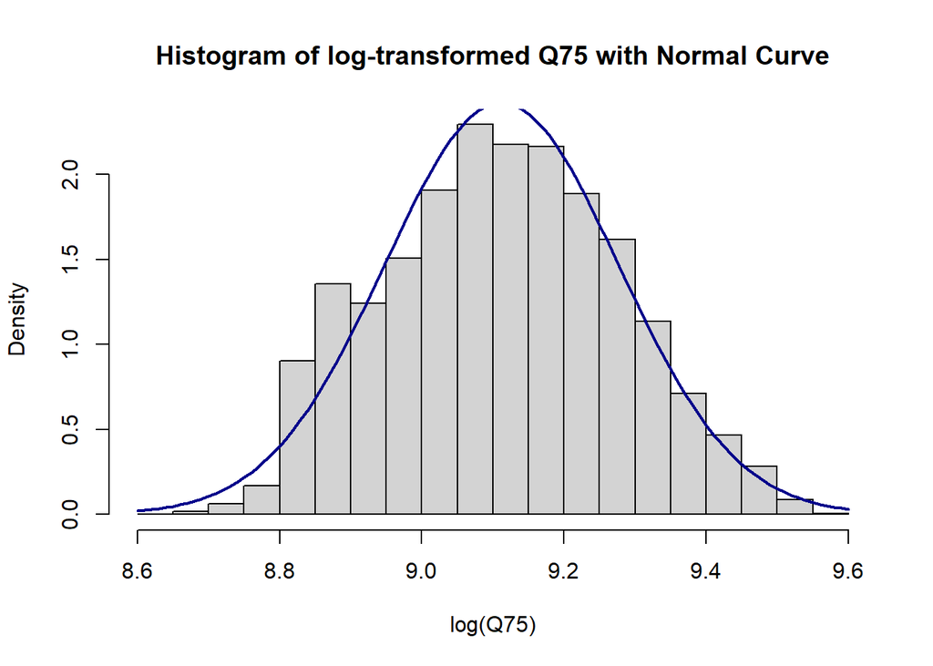

```r
hist(Q75_trans, probability = TRUE, main = "Histogram of log-transformed Q75 with Normal Curve", xlab = "log(Q75)")
curve(dnorm(x, mean = Q75_trans_mean, sd = Q75_trans_sd), col = "darkblue", lwd = 2, add = TRUE, yaxt = "n")
```

#### QQ plot for log-transformed `Q75`

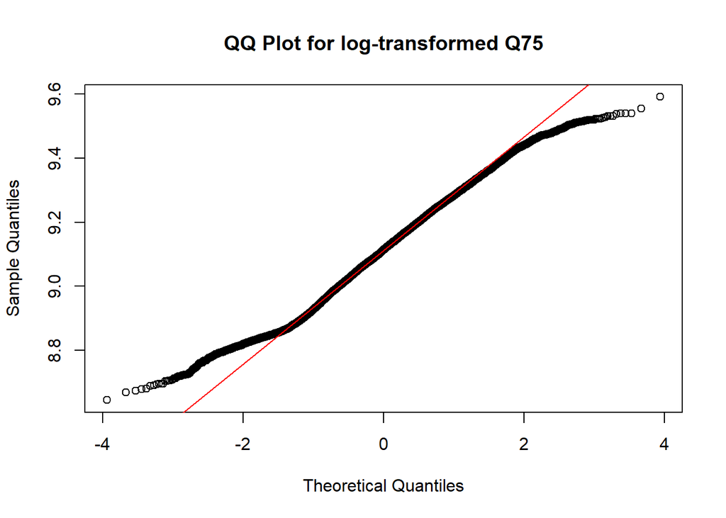

```r
qqnorm(Q75_trans, main = "QQ Plot for log-transformed Q75")
qqline(Q75_trans, col = "red")
```